# Impact of Severe Weather on US Public Health and Economy Between 1950 and 2011

2024-05-16

## Synopsis

Storms and other severe weather events are increasingly causing both public health and economic problems for communities and municipalities. Using the U.S. National Oceanic and Atmospheric Administration’s storm database, which tracks characteristics of major storms and weather events in the United States, we analyzed the public health and economic impacts of severe weather from 1950 and to the end in November 2011. We calculated the public health impacts in two ways: the total number of fatalities and injuries for a given type of weather event and the fatality rate of a weather event, which is the ratio of the number of fatalities for the event and the total number of fatalities and injuries. From these data, we found that tornadoes by far caused the most fatalities and injuries, but that the cold and wind chill had the highest fatality rate. For economic impacts, we measured the total property and crop damages of a weather event. Tornadoes again had by far the highest impact.

## Data Processing

For this analysis, we used the following additional R libraries.

```r
suppressMessages({
        suppressWarnings(
        {
                library(dplyr)          # easier data frame manipulation
                library(stringr)        # string manipulation
                library(ggplot2)        # plotting charts
                library(reshape2)      # for data frame manipulation tools
        })
})
```

The data for this analysis were provided in the form of a comma-separated-value file compressed via the bzip2 algorithm. After extracting the file, we loaded the data into a variable called `data`.

```r
data <- read.csv('repdata_data_StormData.csv')
head(data)
```

|  | STATE__ | BGN_DATE | BGN_TIME | TIME_ZONE | COUNTY | COUNTYNAME | STATE | EVTYPE | BGN_RANGE | BGN_AZI | BGN_LOCATI | END_DATE | END_TIME | COUNTY_END | COUNTYENDN | END_RANGE | END_AZI | END_LOCATI | LENGTH | WIDTH | F | MAG | FATALITIES | INJURIES | PROPDMG | PROPDMGEXP | CROPDMG | CROPDMGEXP | WFO | … |
| --- | --- | --- | --- | --- | --- | --- | --- | --- | --- | --- | --- | --- | --- | --- | --- | --- | --- | --- | --- | --- | --- | --- | --- | --- | --- | --- | --- | --- | --- | --- |
| 1 | 1 | 4/18/1950 0:00:00 | 0130 | CST | 97 | MOBILE | AL | TORNADO | 0 |  |  |  |  | 0 | NA | 0 |  |  | 14.0 | 100 | 3 | 0 | 0 | 15 | 25.0 | K | 0 |  |  | … |
| 2 | 1 | 4/18/1950 0:00:00 | 0145 | CST | 3 | BALDWIN | AL | TORNADO | 0 |  |  |  |  | 0 | NA | 0 |  |  | 2.0 | 150 | 2 | 0 | 0 | 0 | 2.5 | K | 0 |  |  | … |
| 3 | 1 | 2/20/1951 0:00:00 | 1600 | CST | 57 | FAYETTE | AL | TORNADO | 0 |  |  |  |  | 0 | NA | 0 |  |  | 0.1 | 123 | 2 | 0 | 0 | 2 | 25.0 | K | 0 |  |  | … |
| 4 | 1 | 6/8/1951 0:00:00 | 0900 | CST | 89 | MADISON | AL | TORNADO | 0 |  |  |  |  | 0 | NA | 0 |  |  | 0.0 | 100 | 2 | 0 | 0 | 2 | 2.5 | K | 0 |  |  | … |
| 5 | 1 | 11/15/1951 0:00:00 | 1500 | CST | 43 | CULLMAN | AL | TORNADO | 0 |  |  |  |  | 0 | NA | 0 |  |  | 0.0 | 150 | 2 | 0 | 0 | 2 | 2.5 | K | 0 |  |  | … |
| 6 | 1 | 11/15/1951 0:00:00 | 2000 | CST | 77 | LAUDERDALE | AL | TORNADO | 0 |  |  |  |  | 0 | NA | 0 |  |  | 1.5 | 177 | 2 | 0 | 0 | 6 | 2.5 | K | 0 |  |  | … |

### Loading Health Data

For the health data, we pulled out the `EVTYPE` (Event Type), `FATALITIES` and `INJURIES` columns from the data set. To remove inconsistencies in the naming conventions used for the events, we also converted all events to title case.

```r
health_data <- data[c("EVTYPE", "FATALITIES", "INJURIES")]
health_data$EVTYPE <- str_to_title(health_data$EVTYPE)

# Display first few rows
head(health_data)
```

|  | EVTYPE | FATALITIES | INJURIES |
| --- | --- | --- | --- |
| 1 | Tornado | 0 | 15 |
| 2 | Tornado | 0 | 0 |
| 3 | Tornado | 0 | 2 |
| 4 | Tornado | 0 | 2 |
| 5 | Tornado | 0 | 2 |
| 6 | Tornado | 0 | 6 |

### Loading Economic Data

For the economic data, we pulled out the `EVTYPE` column again, as well as the `PROPDMG` (Property Damage) and `CROPDMG` (Crop Damage) columns. We also converted the event types to title case.

```r
econ_data <- data[c("EVTYPE","PROPDMG", "CROPDMG")]
econ_data$EVTYPE <- str_to_title(econ_data$EVTYPE)

# Display first few rows
head(econ_data)
```

|  | EVTYPE | PROPDMG | CROPDMG |
| --- | --- | --- | --- |
| 1 | Tornado | 25.0 | 0 |
| 2 | Tornado | 2.5 | 0 |
| 3 | Tornado | 25.0 | 0 |
| 4 | Tornado | 2.5 | 0 |
| 5 | Tornado | 2.5 | 0 |
| 6 | Tornado | 2.5 | 0 |

## Results

### Analysis of Public Health Impacts

For public health impacts, we took the initial data and grouped it by the event types and added column for the total number of fatalities and injuries. Then we added the fatality rate column. This value was calculated by dividing the total number of fatalities for each event and dividing by the total of the number of fatalities and injuries. Because there are a number of event types without any fatalities or injuries, this calculation produced a number of `NA` values. We removed these entries from the analysis.

```r
# Group data by weather events
event_health_data <- health_data %>% group_by(EVTYPE) %>%
                         summarize(Injuries = sum(INJURIES),
                                   Fatalities = sum(FATALITIES),
                                   Total = sum(INJURIES) + sum(FATALITIES))
# Calculate fatality rates
event_health_data$Fatality_Rate = event_health_data$Fatalities /
                                                      event_health_data$Total
# Remove N/A, fatality rates caused by zero division
event_health_data <- event_health_data[complete.cases(event_health_data), ]

# Display the first few rows
head(event_health_data)
```

| EVTYPE | Injuries | Fatalities | Total | Fatality_Rate |
| --- | --- | --- | --- | --- |
| Avalance | 0 | 1 | 1 | 1.0000000 |
| Avalanche | 170 | 224 | 394 | 0.5685279 |
| Black Ice | 24 | 1 | 25 | 0.0400000 |
| Blizzard | 805 | 101 | 906 | 0.1114790 |
| Blowing Snow | 14 | 2 | 16 | 0.1250000 |
| Brush Fire | 2 | 0 | 2 | 0.0000000 |

```r
# Get top 10 weather events with most fatalities / injuries
top_10_health_data <- event_health_data[c('EVTYPE', 'Injuries', 'Fatalities')]
top_10_health_data <- top_10_health_data[order(-top_10_health_data$Fatalities),
                                                                       ][1:10,]
head(top_10_health_data)
```

| EVTYPE | Injuries | Fatalities |
| --- | --- | --- |
| Tornado | 91346 | 5633 |
| Excessive Heat | 6525 | 1903 |
| Flash Flood | 1777 | 978 |
| Heat | 2100 | 937 |
| Lightning | 5230 | 816 |
| Tstm Wind | 6957 | 504 |

In order to visualize the total impact of the weather events with a stacked bar chart, we converted the table to long form by adding a health outcome column. And to improve readability of the plot, we also changed the column names to more appropriate titles.

```r
# Convert table to long form to make plotting possible
long_top_10_health_data <- melt(top_10_health_data, id='EVTYPE')
# Rename columns to meaningful labels
colnames(long_top_10_health_data) <- c("Event", "Health_Outcome", "Count")

head(long_top_10_health_data)
```

|  | Event | Health_Outcome | Count |
| --- | --- | --- | --- |
| 1 | Tornado | Injuries | 91346 |
| 2 | Excessive Heat | Injuries | 6525 |
| 3 | Flash Flood | Injuries | 1777 |
| 4 | Heat | Injuries | 2100 |
| 5 | Lightning | Injuries | 5230 |
| 6 | Tstm Wind | Injuries | 6957 |

To improve the readability of the plot, we adjusted the overall size of the figure and added appropriate labels and titles.

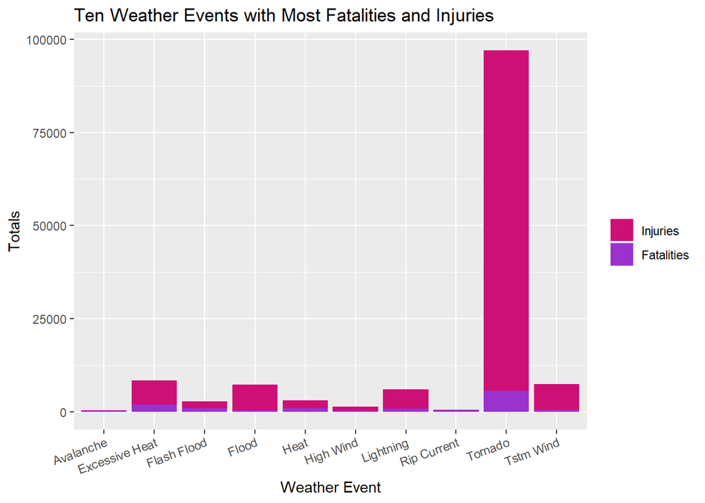

```r
# Adjust plot size
options(repr.plot.width = 10, repr.plot.height = 10)

# Plot bar chart
p <- ggplot(long_top_10_health_data,
       aes(x = Event, y = Count, fill = Health_Outcome)) +
        geom_bar(stat = 'identity') +
        labs(x="Weather Event",
             y="Totals",
             fill='',
             title="Ten Weather Events with Most Fatalities and Injuries") +
        scale_x_discrete(guide = guide_axis(angle = 20)) +
        scale_fill_manual(values=c("deeppink3",
                                   "darkorchid3"))
print(p)
```

Using the total number of fatalities and injuries as the metric of evaluation, tornadoes are the weather event type with greatest total health impact. There are 11.5 times more tornado incidents than the next highest event, excessive heat. And even if we only consider fatalities, tornado incidents caused almost 3 times as many fatalities as the next most common cause, again excessive heat. However, the total number of incidents may not be the best measure of public health impacts. Fatality rates may be more appropriate.

```r
# Calculate Fatality Rate for Top 10
top_10_health_data$Total <- (top_10_health_data$Fatalities +
                                     top_10_health_data$Injuries)
top_10_health_data$Fatality_Rate <- top_10_health_data$Fatalities /
                                        top_10_health_data$Total
# Sort by Fatality Rates
top_10_health_data <- top_10_health_data[order(-top_10_health_data$Fatality_Rate)
                                                                            , ]
# Display results
top_10_health_data
```

| EVTYPE | Injuries | Fatalities | Total | Fatality_Rate |
| --- | --- | --- | --- | --- |
| Rip Current | 232 | 368 | 600 | 0.61333333 |
| Avalanche | 170 | 224 | 394 | 0.56852792 |
| Flash Flood | 1777 | 978 | 2755 | 0.35499093 |
| Heat | 2100 | 937 | 3037 | 0.30852815 |
| Excessive Heat | 6525 | 1903 | 8428 | 0.22579497 |
| High Wind | 1137 | 248 | 1385 | 0.17906137 |
| Lightning | 5230 | 816 | 6046 | 0.13496527 |
| Tstm Wind | 6957 | 504 | 7461 | 0.06755127 |
| Flood | 6789 | 470 | 7259 | 0.06474721 |
| Tornado | 91346 | 5633 | 96979 | 0.05808474 |

As seen in the table above, the only weather event types with fatality rates above 50% are rip currents and avalanches with fatality rates of 61.3% and 56.9% respectively. Interestingly, the weather event with lowest fatality rate among these events with highest total of incidents were tornadoes. So tornadoes occur most frequently but cause the fewest fatalities as a proportion of the number of incidents.

But these are only the weather events with highest total occurrences. To expand our analysis, we then widened it to include all of the weather events in the data set.

```r
# Events with fatality rate of 1.0
fatality_rate_1_health_data <- event_health_data[event_health_data$Fatality_Rate
                                                                      == 1.0, ]
# Sort by total number of incidents in ascending order
fatality_rate_1_health_data <- fatality_rate_1_health_data[
                                    order(-fatality_rate_1_health_data$Total), ]
# Get first few rows
head(fatality_rate_1_health_data)
```

| EVTYPE | Injuries | Fatalities | Total | Fatality_Rate |
| --- | --- | --- | --- | --- |
| Unseasonably Warm And Dry | 0 | 29 | 29 | 1 |
| Tornadoes, Tstm Wind, Hail | 0 | 25 | 25 | 1 |
| Record/Excessive Heat | 0 | 17 | 17 | 1 |
| Cold And Snow | 0 | 14 | 14 | 1 |
| Flash Flood/Flood | 0 | 14 | 14 | 1 |
| Hypothermia/Exposure | 0 | 7 | 7 | 1 |

Although these weather events warrant further exploration, we decided to exclude them in our analysis because they cause so few fatalities. Unseasonably warm and dry weather, which occurred most among those with fatality rates of 1.0, only had 29 incidents in the data set. Since we’re looking at the weather events with the greatest impacts, the impact of these events was minimal.

```r
# Events with fatality rates above 0.5 and below 1.0
upper_half_fatality_rates <- event_health_data[(event_health_data$Fatality_Rate
                          < 1.0) & (event_health_data$Fatality_Rate >= 0.5), ]

# Sort by fatality rate in ascending order
upper_half_fatality_rates <- upper_half_fatality_rates[
        order(-upper_half_fatality_rates$Fatality_Rate), ]
```

To further expand our analysis, we also plotted the data for the 10 events with the highest rates.

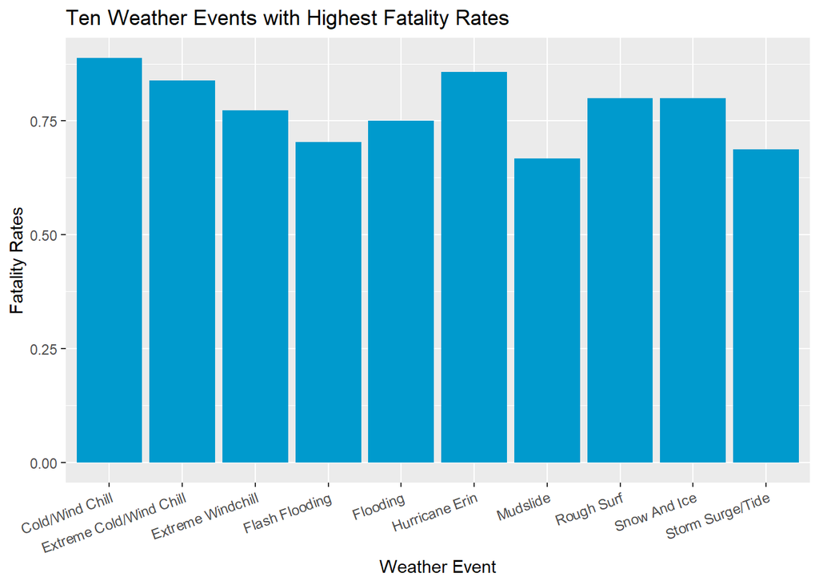

```r
# Plot 10 highest fatality rates
p <- ggplot(data=upper_half_fatality_rates[1:10, ],
            aes(x=EVTYPE, y=Fatality_Rate)) +
            geom_bar(stat="identity", fill="deepskyblue3") +
            labs(x="Weather Event",
                 y="Fatality Rates",
                 title="Ten Weather Events with Highest Fatality Rates") +
            scale_x_discrete(guide = guide_axis(angle = 20))
print(p)
```

### Analysis of Economic Impacts

```r
# Group data by weather events
event_econ_data <- econ_data %>% group_by(EVTYPE) %>%
                   summarize(Property_Damage = sum(PROPDMG),
                             Crop_Damage = sum(CROPDMG),
                             Total = sum(PROPDMG) + sum(CROPDMG))

# Order by total damages in descending order
event_econ_data <- event_econ_data[order(-event_econ_data$Total), ]

# Display the few rows of the data
head(event_econ_data)
```

| EVTYPE | Property_Damage | Crop_Damage | Total |
| --- | --- | --- | --- |
| Tornado | 3212258.2 | 100018.52 | 3312276.7 |
| Flash Flood | 1420124.6 | 179200.46 | 1599325.1 |
| Tstm Wind | 1335995.6 | 109202.60 | 1445198.2 |
| Hail | 688693.4 | 579596.28 | 1268289.7 |
| Flood | 899938.5 | 168037.88 | 1067976.4 |
| Thunderstorm Wind | 876844.2 | 66791.45 | 943635.6 |

To help visualize the total impact of the most damaging weather events, we selected the ten events with highest totals and scaled the damages to the millions of dollars. Then to plot this data, we converted the table to long form by adding a damage type column and renamed the columns with more appropriate labels.

```r
# Get top 10 weather events with most economic damages
top_10_econ_data <- event_econ_data[c('EVTYPE', 'Property_Damage',
                                                        'Crop_Damage')][1:10, ]
# Rescale for plotting
top_10_econ_data$Crop_Damage <- top_10_econ_data$Crop_Damage / 1000000
top_10_econ_data$Property_Damage <- top_10_econ_data$Property_Damage / 1000000

# Convert table to long form to make plotting possible
long_top_10_econ_data <- melt(top_10_econ_data, id='EVTYPE')

# Rename columns to meaningful labels
colnames(long_top_10_econ_data) <- c("Event", "Damage_Type", "Damages")

# Display the table
long_top_10_econ_data
```

| Event | Damage_Type | Damages |
| --- | --- | --- |
| Tornado | Property_Damage | 3.21225816 |
| Flash Flood | Property_Damage | 1.42012459 |
| Tstm Wind | Property_Damage | 1.33599561 |
| Hail | Property_Damage | 0.68869338 |
| Flood | Property_Damage | 0.89993848 |
| Thunderstorm Wind | Property_Damage | 0.87684417 |
| Lightning | Property_Damage | 0.60335178 |
| Thunderstorm Winds | Property_Damage | 0.44629318 |
| High Wind | Property_Damage | 0.32473156 |
| Winter Storm | Property_Damage | 0.13272059 |

[output cut: 10 more lines]

Like the public health impacts above, we chose to plot the data using a stacked bar chart. This time we stacked property and crop damages.

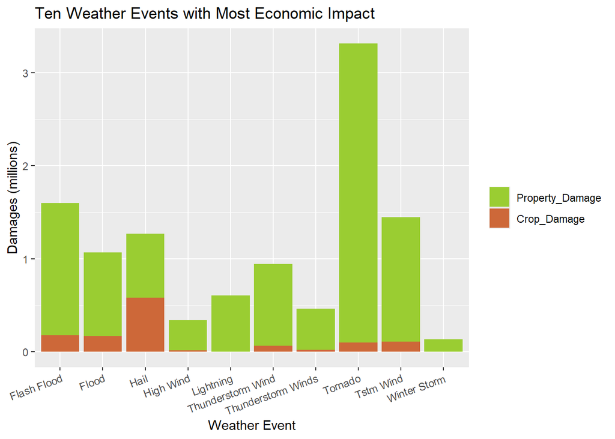

```r
# Adjust plot size
options(repr.plot.width = 10, repr.plot.height = 10)

# Plot bar chart
p <- ggplot(long_top_10_econ_data,
            aes(x = Event, y = Damages, fill = Damage_Type)) +
     geom_bar(stat = 'identity') +
     labs(x="Weather Event",
             y="Damages (millions)",
             fill='',
             title="Ten Weather Events with Most Economic Impact") +
      scale_x_discrete(guide = guide_axis(angle = 20)) +
      scale_fill_manual(values=c("olivedrab3",
                                   "sienna3"))
print(p)
```

Although hail is responsible for the most crop damage, tornadoes cause the most damage by far. It’s responsible for more than twice as much damage as the next most damaging weather event, flash floods.